# KI2026: Assignment 1 – R Programming and Data Visualisation

Ayano Fushida

2026-11-01

# Task 3: Introduction to R and Online R Course

Install Bioconductor and tidyverse.

```r
# Install Bioconductor
if (!require("BiocManager", quietly = TRUE)) {
  install.packages("BiocManager")
}

BiocManager::install(version = "3.22")

# Install tidyverse
install.packages("tidyverse")
```

# Task 4: Basic R Operations

### 4.1 What is the square root of 10?

```r
sqrt(10)
```

```
## [1] 3.162278
```

### 4.2 What is the logarithm of 32 to the base 2?

```r
log2(32)
```

```
## [1] 5
```

### 4.3 What is the sum of the numbers from 1 to 100?

```r
sum(1:100)
```

```
## [1] 5050
```

### 4.4 What is the sum of all even numbers from 2 to 1000?

`seq(2, 1000, by = 2)` generates 2, 4, 6, …, 1000.

```r
sum(seq(2, 1000, by = 2))
```

```
## [1] 250500
```

### 4.5 How many pairwise comparisons are there for 100 genes?

`choose()` calculates the number of possible combinations.

```r
choose(100, 2)
```

```
## [1] 4950
```

### 4.6 How many ways are there to arrange 100 genes in groups of three?

```r
choose(100, 3)
```

```
## [1] 161700
```

# Task 5: Using R Example Datasets

### 5.1 Use the R internal CO2 dataset

```r
data(CO2)
head(CO2)
```

```
##   Plant   Type  Treatment conc uptake
## 1   Qn1 Quebec nonchilled   95   16.0
## 2   Qn1 Quebec nonchilled  175   30.4
## 3   Qn1 Quebec nonchilled  250   34.8
## 4   Qn1 Quebec nonchilled  350   37.2
## 5   Qn1 Quebec nonchilled  500   35.3
## 6   Qn1 Quebec nonchilled  675   39.2
```

### 5.2 Describe briefly the content of the CO2 dataset

The CO2 data frame has 84 rows and 5 columns from an experiment on the cold tolerance of the grass species *Echinochloa crus-galli*.

- **Plant:** Plant ID.
- **Type:** Origin of the plant (Quebec or Mississippi).
- **Treatment:** Whether the plants were chilled or nonchilled.
- **conc:** Ambient carbon dioxide concentration (mL/L).
- **uptake:** Carbon dioxide uptake rate (µmol/m² sec).

### 5.3 What is the average and median CO2 uptake of plants from Quebec and Mississippi?

```r
# Check plant origins
levels(CO2$Type)
```

```
## [1] "Quebec"      "Mississippi"
```

```r
# Calculate mean CO2 uptake by plant origin
tapply(CO2$uptake, CO2$Type, mean)
```

```
##      Quebec Mississippi
##    33.54286    20.88333
```

```r
# Calculate median CO2 uptake by plant origin
tapply(CO2$uptake, CO2$Type, median)
```

```
##      Quebec Mississippi
##       37.15       19.30
```

### 5.4 In the airway example data, how many genes are expressed in each sample? How many genes are not expressed in any sample?

The airway package can be installed using:

```r
if (!require("BiocManager", quietly = TRUE)) {
  install.packages("BiocManager")
}

BiocManager::install("airway")
```

Load the dataset:

```r
library(airway)
data(airway)

counts <- assay(airway)

head(counts)
```

```
##                 SRR1039508 SRR1039509 SRR1039512 SRR1039513 SRR1039516
## ENSG00000000003        679        448        873        408       1138
## ENSG00000000005          0          0          0          0          0
## ENSG00000000419        467        515        621        365        587
## ENSG00000000457        260        211        263        164        245
## ENSG00000000460         60         55         40         35         78
## ENSG00000000938          0          0          2          0          1
##                 SRR1039517 SRR1039520 SRR1039521
## ENSG00000000003       1047        770        572
## ENSG00000000005          0          0          0
## ENSG00000000419        799        417        508
## ENSG00000000457        331        233        229
## ENSG00000000460         63         76         60
## ENSG00000000938          0          0          0
```

**Number of expressed genes in each sample**

A gene is considered expressed when its raw count is greater than zero.

```r
# Count expressed genes per sample
genes_per_sample <- apply(counts, 2, function(x) {
  sum(x > 0)
})

genes_per_sample
```

```
## SRR1039508 SRR1039509 SRR1039512 SRR1039513 SRR1039516 SRR1039517 SRR1039520
##      24633      24527      25699      23124      25508      25998      24662
## SRR1039521
##      23991
```

`MARGIN = 2` applies the function to each column (sample).

**Number of genes not expressed in any sample**

```r
# Count genes not expressed in any sample
genes_not_expressed <- sum(
  apply(counts, 1, function(x) {
    all(x == 0)
  })
)

genes_not_expressed
```

```
## [1] 30208
```

`MARGIN = 1` applies the function to each row (gene). `all()` checks whether the expression count is zero in every sample.

# Task 6: R Functions

### 6.1 Write a function that calculates the ratio of the mean and median of a given vector

```r
# Define a vector
X <- c(3, 13, 11, 20, 26)

# Create a function
mean_median_ratio <- function(x) {
  mean(x) / median(x)
}

# Calculate the ratio
mean_median_ratio(X)
```

```
## [1] 1.123077
```

### 6.2 Write a function that ignores the lowest and highest values from a given vector and calculates the mean

```r
trimmed_mean <- function(x) {
  x <- x[-c(which.min(x), which.max(x))]
  mean(x)
}

trimmed_mean(X)
```

```
## [1] 14.66667
```

### 6.3 Read about piping. Write a short explanation of why, how and when not to use pipes

**Additional explanation** Pipes connect multiple operations, making data processing more readable and sequential. They are useful for chaining data manipulation steps but should be avoided when operations become complex or require multiple inputs and outputs.

**Assignment answer (max. 300 characters, excluding spaces)** Pipes can be used with operators such as `%>%`, `%T%`, `%$%` and `%<>%`. Avoid pipes for 10+ steps, multiple inputs or outputs, or complex dependencies. Use named intermediate objects to simplify debugging and clarify intent.

### 6.4 Familiarise yourself with the apply-family of functions. Write a short explanation of why they could be useful in your work

**Additional explanation** Apply-family functions automate calculations across genes, samples and conditions, reducing repetitive code and efficiently processing RNA-seq and ATAC-seq data.

**Assignment answer (max. 300 characters, excluding spaces)** They streamline RNA-seq and ATAC-seq analyses by automating gene expression and peak comparisons across cell-cycle phases, treatments and replicates, enabling efficient calculations and summarisation with less repetitive code.

# Task 7: Data Visualisation and Missing Values

### 7.1 Compare the distributions of body heights between Jedi and Sith

```r
magic_guys <- read.csv("Week1-Task7data/magic_guys.csv")

head(magic_guys)
```

```
##   uniqId species length weight
## 1     p1    jedi  174.6   71.3
## 2     p2    jedi  252.2   70.8
## 3     p3    jedi  229.8   70.7
## 4     p4    jedi  176.2   80.4
## 5     p5    jedi  213.3   82.0
## 6     p6    jedi  112.5   64.2
```

#### A. Histograms using base R

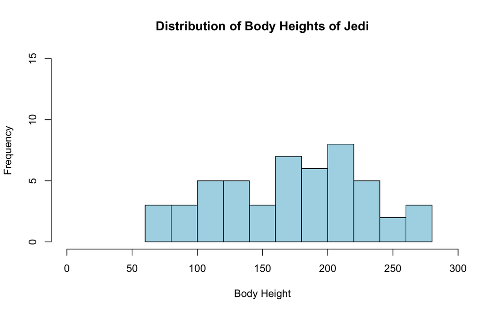

```r
# Jedi histogram
hist(
  magic_guys$length[magic_guys$species == "jedi"],
  breaks = 10,
  col = "lightblue",
  xlim = c(0, 300),
  ylim = c(0, 15),
  main = "Distribution of Body Heights of Jedi",
  xlab = "Body Height",
  ylab = "Frequency"
)
```

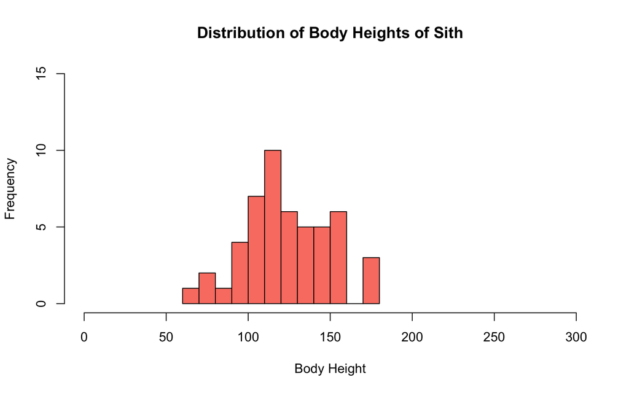

```r
# Sith histogram
hist(
  magic_guys$length[magic_guys$species == "sith"],
  breaks = 10,
  col = "salmon",
  xlim = c(0, 300),
  ylim = c(0, 15),
  main = "Distribution of Body Heights of Sith",
  xlab = "Body Height",
  ylab = "Frequency"
)
```

#### B. Histogram using ggplot2

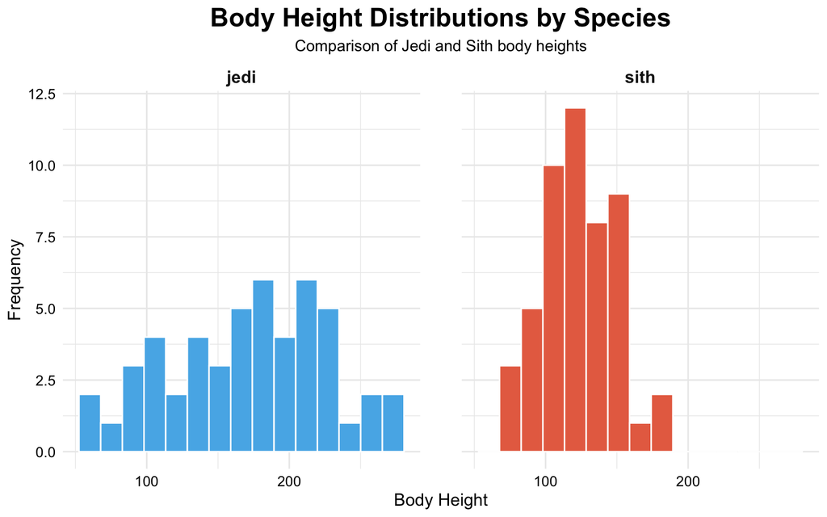

```r
library(ggplot2)

h <- ggplot(magic_guys, aes(x = length, fill = species)) +
  geom_histogram(
    bins = 15,
    color = "white"
  ) +
  scale_fill_manual(values = c(
    "jedi" = "#56B4E9",
    "sith" = "#E76F51"
  )) +
  facet_grid(. ~ species) +
  labs(
    x = "Body Height",
    y = "Frequency",
    title = "Body Height Distributions by Species",
    subtitle = "Comparison of Jedi and Sith body heights"
  ) +
  theme_minimal() +
  theme(
    plot.title = element_text(size = 18, face = "bold", hjust = 0.5),
    plot.subtitle = element_text(size = 11, hjust = 0.5),
    axis.title = element_text(size = 12),
    axis.text = element_text(size = 10, color = "black"),
    strip.text = element_text(size = 12, face = "bold"),
    legend.position = "none",
    panel.spacing = unit(2, "lines")
  )

h
```

#### C. Boxplot using ggplot2

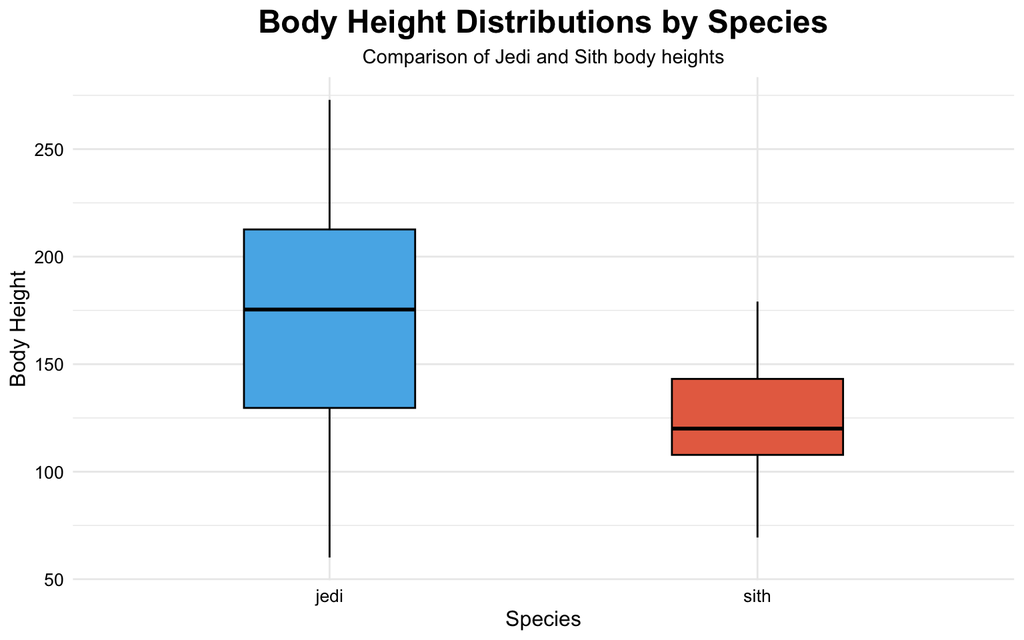

```r
b <- ggplot(magic_guys, aes(x = species, y = length, fill = species)) +
  geom_boxplot(
    color = "black",
    width = 0.4
  ) +
  scale_fill_manual(values = c(
    "jedi" = "#56B4E9",
    "sith" = "#E76F51"
  )) +
  labs(
    x = "Species",
    y = "Body Height",
    title = "Body Height Distributions by Species",
    subtitle = "Comparison of Jedi and Sith body heights"
  ) +
  theme_minimal() +
  theme(
    plot.title = element_text(size = 18, face = "bold", hjust = 0.5),
    plot.subtitle = element_text(size = 11, hjust = 0.5),
    axis.title = element_text(size = 12),
    axis.text = element_text(size = 10, color = "black"),
    strip.text = element_text(size = 12, face = "bold"),
    legend.position = "none"
  )

b
```

#### D. Save the plots in PNG, PDF and SVG formats

```r
dir.create(
  "Figures",
  showWarnings = FALSE,
  recursive = TRUE
)

# Save histogram
ggsave("Figures/histogram.png", plot = h, dpi = 300)
ggsave("Figures/histogram.pdf", plot = h)
ggsave("Figures/histogram.svg", plot = h)

# Save boxplot
ggsave("Figures/boxplot.png", plot = b, dpi = 300)
ggsave("Figures/boxplot.pdf", plot = b)
ggsave("Figures/boxplot.svg", plot = b)
```

- **PNG:** When inserting a figure into PowerPoint or Word for presentations.
- **PDF:** When submitting figures for a research paper or thesis.
- **SVG:** When further editing and customising a figure is required.

### 7.2 Load the gene expression data matrix from microarray_data.tab

```r
microarray <- read.delim(
  "Week1-Task7data/microarray_data.tab",
  header = TRUE,
  sep = "\t"
)

head(microarray)
```

```
##       g1 g2     g3    g4     g5     g6     g7     g8     g9    g10    g11
## 1  1.802 NA -0.182 1.312  3.497  0.439  0.777  0.379  0.336  0.877 -0.016
## 2     NA NA  7.693    NA  0.193 -1.383 -1.309 -0.424 -0.270 -0.519  1.448
## 3  1.079 NA  1.556 1.652     NA  0.460  0.715  0.375 -0.138 -0.261  0.207
## 4  3.607 NA  1.914    NA  1.400  1.109  2.143  1.571 -0.271 -0.309 -0.658
## 5 -1.700 NA  0.943    NA -0.170     NA -0.041     NA -0.069  1.533  0.177
## 6     NA NA  0.043    NA  0.729 -0.089  0.209 -0.308  0.474 -0.655  0.249
##      g12    g13    g14    g15    g16    g17 g18    g19    g20    g21    g22
## 1  0.977  0.114  1.411 -0.131  1.198 -0.532  NA  0.006  0.540  0.511  0.079
## 2  0.229 -0.079     NA  0.402     NA  0.596  NA -0.833 -1.425     NA -1.553
## 3  0.154 -0.066  0.215  0.380 -0.155 -0.185  NA  0.655 -0.460 -1.474  0.391
## 4 -0.089  0.421 -0.075  1.039 -0.442  0.823  NA  0.014 -0.098 -1.199 -0.347
## 5  0.461  0.228  0.025  0.299 -0.705  0.212  NA -0.051 -0.553  0.366 -0.668
## 6 -0.433  0.361 -0.603 -0.280     NA -0.384  NA  0.477  0.397  0.238  0.685
##      g23    g24    g25    g26    g27    g28    g29    g30    g31    g32    g33
```

[output cut: 622 more lines]

#### A. How big is the matrix in terms of rows and columns?

```r
nrow(microarray)
```

```
## [1] 553
```

```r
ncol(microarray)
```

```
## [1] 1000
```

#### B. Count the missing values per gene and visualise this result

```r
# Count missing values per gene
missing_per_gene <- colSums(is.na(microarray))

head(missing_per_gene)
```

```
##  g1  g2  g3  g4  g5  g6
## 130 104  74  93  81  30
```

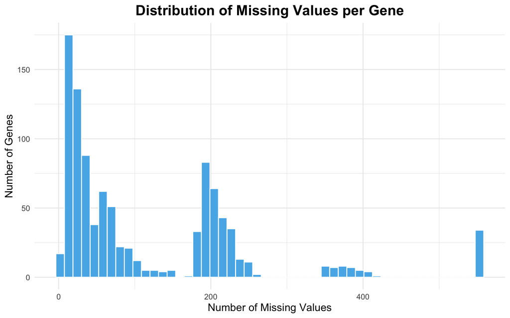

```r
# Convert into a data frame for ggplot
missing_df <- data.frame(
  missing_count = missing_per_gene
)

# Visualise distribution of missing values
ggplot(missing_df, aes(x = missing_count)) +
  geom_histogram(
    bins = 50,
    fill = "#56B4E9",
    color = "white"
  ) +
  labs(
    title = "Distribution of Missing Values per Gene",
    x = "Number of Missing Values",
    y = "Number of Genes"
  ) +
  theme_minimal() +
  theme(
    plot.title = element_text(
      size = 16,
      face = "bold",
      hjust = 0.5
    ),
    axis.title = element_text(size = 12)
  )
```

#### C. Find the genes with more than 10%, 20% and 50% missing values

`sapply()` applies the same calculation to each column and simplifies the result into a named vector.

```r
missing_percentage <- sapply(microarray, function(x) {
  mean(is.na(x)) * 100
})

# More than 10%
genes_10 <- names(missing_percentage[missing_percentage > 10])

# More than 20%
genes_20 <- names(missing_percentage[missing_percentage > 20])

# More than 50%
genes_50 <- names(missing_percentage[missing_percentage > 50])

length(genes_10)
```

```
## [1] 529
```

```r
length(genes_20)
```

```
## [1] 377
```

```r
length(genes_50)
```

```
## [1] 74
```

#### D. Replace missing values with the average expression value for each gene

`lapply()` applies a function to every column. `na.rm = TRUE` excludes missing values when calculating the mean.

```r
microarray_imputed <- as.data.frame(
  lapply(microarray, function(x) {
    x[is.na(x)] <- mean(x, na.rm = TRUE)
    x
  })
)

# Check whether any missing values remain
sum(is.na(microarray_imputed))
```

```
## [1] 18802
```

Mean imputation should be used with caution because it can affect the distribution and variability of gene expression values.

### 7.3 Visualise the CO2 dataset in a way that gives a deeper understanding of the data. What do you see?

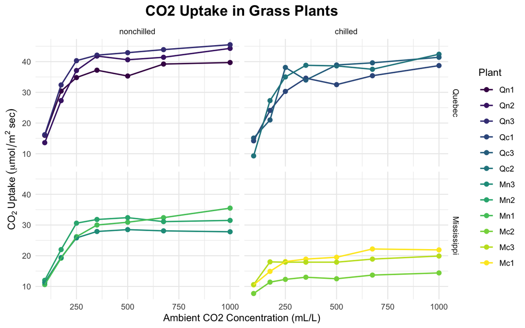

```r
data(CO2)

ggplot(CO2, aes(
  x = conc,
  y = uptake,
  group = Plant,
  colour = Plant
)) +
  geom_point(size = 2) +
  geom_line(linewidth = 0.7) +
  facet_grid(Type ~ Treatment) +
  labs(
    title = "CO2 Uptake in Grass Plants",
    x = "Ambient CO2 Concentration (mL/L)",
    y = expression(CO[2]~Uptake~(mu*mol/m^2~sec))
  ) +
  theme_minimal() +
  theme(
    plot.title = element_text(
      size = 16,
      face = "bold",
      hjust = 0.5
    )
  )
```

CO2 uptake increased as ambient CO2 concentration increased, eventually reaching a plateau. Chilling reduced CO2 uptake in both plant origins, with a much greater reduction in Mississippi plants than in Quebec plants, suggesting that the response to chilling may vary depending on plant origin.

# Task 8: Tidybiology

Install the tidybiology package:

```r
install.packages("devtools")

devtools::install_github("hirscheylab/tidybiology")
```

Load the package and datasets:

```r
library(tidybiology)
library(dplyr)

data("chromosome")
data("proteins")
```

## 8.1 Chromosome dataset

### A. Extract summary statistics (mean, median and maximum) for variations, protein-coding genes and miRNAs

```r
chromosome |>
  summarise(
    across(
      c(variations, protein_codinggenes, mi_rna),
      list(
        mean = ~mean(.x, na.rm = TRUE),
        median = ~median(.x, na.rm = TRUE),
        maximum = ~max(.x, na.rm = TRUE)
      )
    )
  )
```

```
## # A tibble: 1 × 9
##   variations_mean variations_median variations_maximum protein_codinggenes_mean
##             <dbl>             <dbl>              <dbl>                    <dbl>
## 1        6484572.           6172346           12945965                     850.
## # ℹ 5 more variables: protein_codinggenes_median <dbl>,
## #   protein_codinggenes_maximum <int>, mi_rna_mean <dbl>, mi_rna_median <dbl>,
## #   mi_rna_maximum <int>
```

### B. How does chromosome size distribute?

```r
# Check column type
class(chromosome$basepairs)
```

```
## [1] "numeric"
```

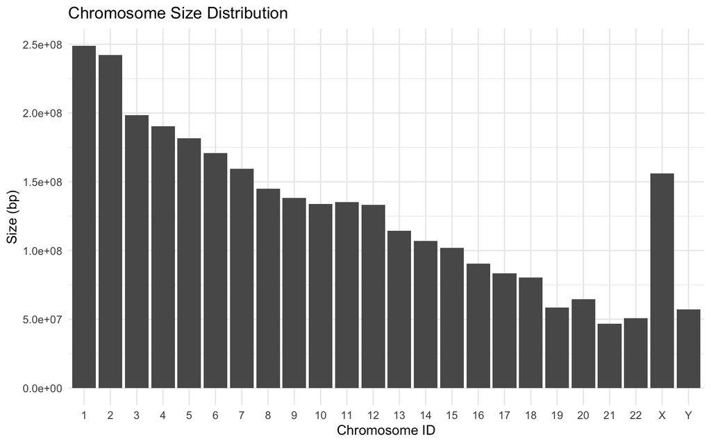

```r
# Convert basepairs to integer
chromosome$basepairs <- as.integer(chromosome$basepairs)

ggplot(chromosome, aes(x = id, y = basepairs)) +
  geom_col() +
  labs(
    x = "Chromosome ID",
    y = "Size (bp)",
    title = "Chromosome Size Distribution"
  ) +
  theme_minimal()
```

### C. Does the number of protein-coding genes or miRNAs correlate with chromosome length?

#### Chromosome length and protein-coding genes

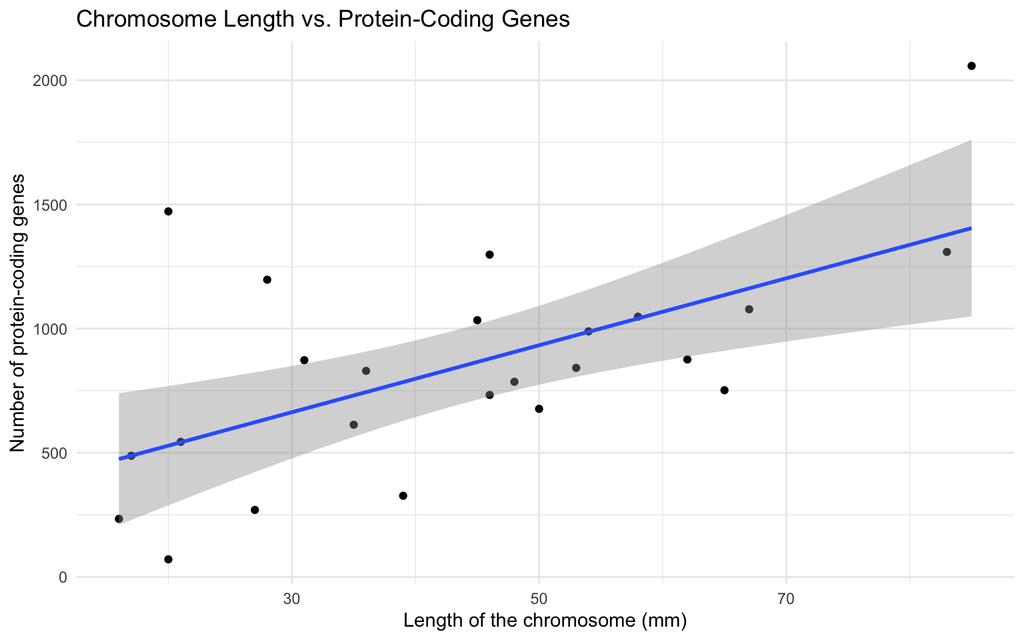

```r
ggplot(chromosome, aes(
  x = length_mm,
  y = protein_codinggenes
)) +
  geom_point() +
  geom_smooth(method = "lm") +
  labs(
    x = "Length of the chromosome (mm)",
    y = "Number of protein-coding genes",
    title = "Chromosome Length vs. Protein-Coding Genes"
  ) +
  theme_minimal()
```

#### Chromosome length and miRNAs

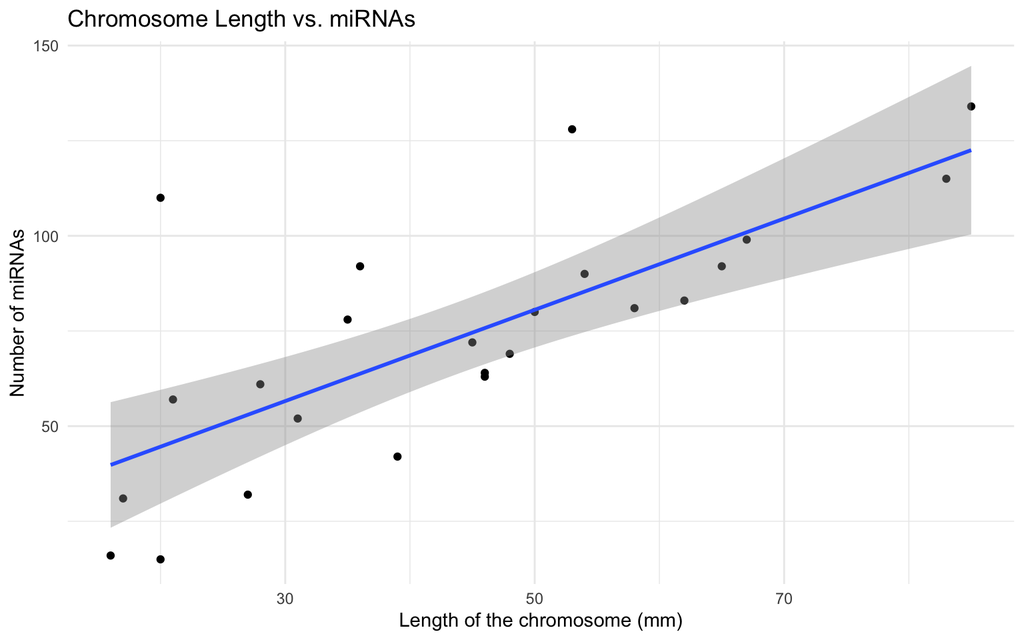

```r
ggplot(chromosome, aes(
  x = length_mm,
  y = mi_rna
)) +
  geom_point() +
  geom_smooth(method = "lm") +
  labs(
    x = "Length of the chromosome (mm)",
    y = "Number of miRNAs",
    title = "Chromosome Length vs. miRNAs"
  ) +
  theme_minimal()
```

#### Pearson correlation tests

```r
# Correlation between chromosome length and protein-coding genes
cor.test(
  chromosome$length_mm,
  chromosome$protein_codinggenes,
  method = "pearson"
)
```

```
##
##  Pearson's product-moment correlation
##
## data:  chromosome$length_mm and chromosome$protein_codinggenes
## t = 3.5734, df = 22, p-value = 0.001697
## alternative hypothesis: true correlation is not equal to 0
## 95 percent confidence interval:
##  0.2681836 0.8111233
## sample estimates:
##       cor
## 0.6060185
```

```r
# Correlation between chromosome length and miRNAs
cor.test(
  chromosome$length_mm,
  chromosome$mi_rna,
  method = "pearson"
)
```

```
##
##  Pearson's product-moment correlation
##
## data:  chromosome$length_mm and chromosome$mi_rna
## t = 5.1099, df = 22, p-value = 4.039e-05
## alternative hypothesis: true correlation is not equal to 0
## 95 percent confidence interval:
##  0.4742341 0.8789011
## sample estimates:
##       cor
## 0.7366973
```

## 8.2 Protein dataset

### A. Calculate the same summary statistics for protein length and mass

```r
summary(proteins[, c("length", "mass")])
```

```
##      length             mass
##  Min.   :    2.0   Min.   :    260
##  1st Qu.:  251.0   1st Qu.:  27940
##  Median :  414.0   Median :  46140
##  Mean   :  557.2   Mean   :  62061
##  3rd Qu.:  669.0   3rd Qu.:  74755
##  Max.   :34350.0   Max.   :3816030
```

### B. Visualise the relationship between protein length and mass

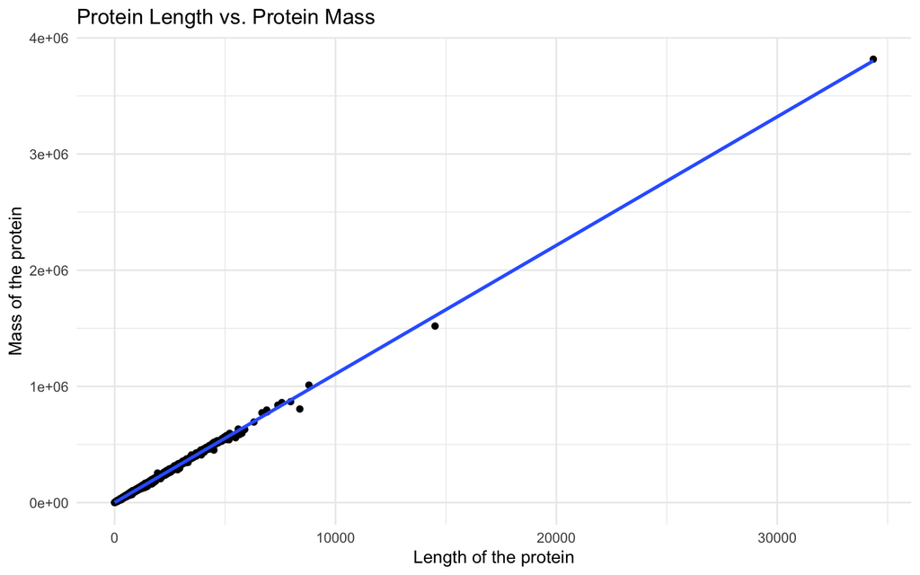

```r
ggplot(proteins, aes(x = length, y = mass)) +
  geom_point() +
  geom_smooth(method = "lm") +
  labs(
    x = "Length of the protein",
    y = "Mass of the protein",
    title = "Protein Length vs. Protein Mass"
  ) +
  theme_minimal()
```